# genomicSimulation Vignette

## 5.1 Simple Example Breeding Scheme

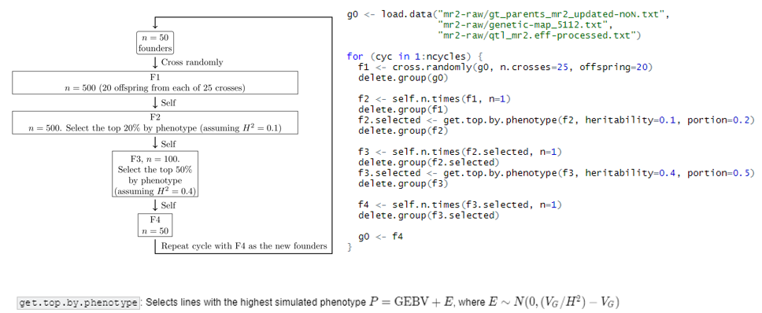

A demonstration of an implementation of a simplified breeding scheme. This process was run for two conditions, one with selection inside `get.top.by.phenotype` done across all individuals in the set, the other with selection done within each family of lines descended from one of the original 25 crosses.

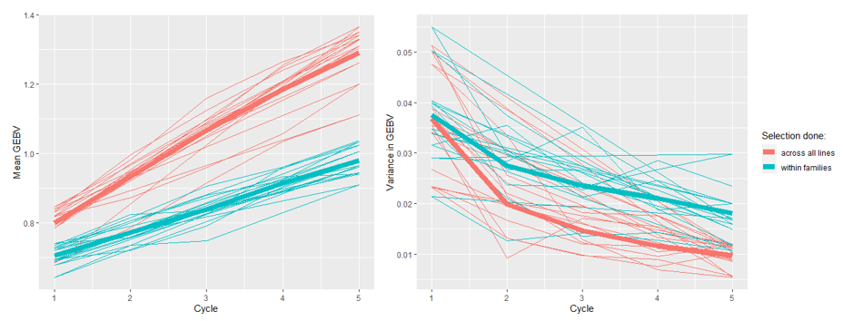

## 5.2 Selection by Simulated Phenotype

```r
f <- cross.randomly(g0, n.crosses=5, offspring=3)

f.info <- see.group.gebvs(f)

# Create the masked values. In this case, a normally distributed term with sd corresponding
# to environmental variance is added to each GEBV
H2 <- 0.5  #estimate the heritability of the GEBV's trait at this step
Vg <- var(f.info$GEBV)
Ve <- Vg/H2 - Vg  # using the formula H2 = Vg/(Vg + Ve) to find the environmental variation
f.info$Pheno <- f.info$GEBV + rnorm(length(f.info$GEBV), mean=0, sd = sqrt(Ve))

# Sort the list by phenotypes
f.info <- f.info[order(f.info$Pheno, decreasing=TRUE),]
# Send the top 10 phenotypes to a new group
fselected <- make.group(f.info$i[1:10])

# (delete the non-selected genotypes)
delete.group(f)
```

```
#> 5 genotypes were deleted
#> [1] 0
```

```r
# Then generate further generations from the selected genotypes
f2 <- cross.randomly(fselected, n.crosses=100)
# ...
delete.group(f2)
```

```
#> 100 genotypes were deleted
#> [1] 0
```

# 6 Indexes

## 6.1 Function Index

Use the R documentation (eg. type `?load.data` in the RStudio console) to get descriptions of these functions.

Loading data:

- `group <- load.data(allele.file, map.file, effect.file = NULL)`
- `group <- load.more.genotypes(allele.file)`
- `load.different.effects(effect.file)`

Simulating crossing:

- `group <- cross(parent1,parent2,[settings])`
- `group <- cross.randomly(group,n.crosses,[settings])`
- `group <- cross.combinations(cross.file,[settings])`
- `group <- cross.dc.combinations(cross.file,[settings])`
- `group <- cross.all.pairs(group,[settings])`
- `group <- self.n.times(group,n,[settings])`
- `group <- make.doubled.haploids(group,[settings])`

Performing selection:

- `selected.group <- select.by.gebv(from.group, low.score.best = FALSE, percentage OR number)`
- For more customised selection, use the process
  - `info <- see.group.gebvs(group)`
  - `selected.info <-`[some R manipulation on `info` that performs the custom selection]
  - `selected.group <- make.group(selected.info$I)`

Modify groupings:

- `delete.group(group)`
- `group <- combine.groups(groups)`
- `group <- make.group(indexes)`
- `[vector of groups] <- break.group.into.individuals(group)`
- `[vector of groups] <- break.group.into.families(group)`

Save data (saves results to files):

- `save.genome.model(filename)`
- `save.genotypes(filename, group = NULL, type = "R")`
- `save.allele.counts(filename, group = NULL, allele)`
- `save.pedigrees(filename, group = NULL, type = "R")`
- `save.GEBVs(filename, group = NULL)`
- `save.local.GEBVs(filename, block.file, group = NULL)`

View data (pulls data into R dataframes):

- `[dataframe containing current existing groups and their sizes] <- see.existing.groups()`
- `[vector containing the chosen data] <- see.group.data(group, data.type)`
- `[index and GEBV for each group member] <- see.group.gebvs(group)`

Identify recombination events:

- `find.crossovers(parentage.file, out.file, window.size = 1, certainty = TRUE)`
- `find.plot.crossovers(parentage.file, out.file, window.size = 1, certainty = TRUE)`

Data Storage:

- `clear.simdata()`

## 6.2 Crossing Function Settings

All crossing functions take in a common set of settings. These are briefly described below.

- `offspring` : A setting representing the number of times to do each cross.
- `retain` : A boolean, repesenting whether to save the generated genotypes to memory or discard them. You may wish to discard them but save to file if you are generating too many crosses to save into memory.
- `give.names` : A boolean representing whether or not to produce names for the new genotypes generated. The names produced would have format [name.prefix][id]
- `name.prefix` : A string. If give.names is TRUE, the id is concatenated to this to produce the name of each new genotype.
- `track.pedigree` :A boolean representing whether or not to save the ids of the parents of each new genotype to the new genotype’s pedigree. If this is false, the new genotype’s pedigree is unknown.
- `give.ids` : A boolean representing whether or not to allocate each new genotype an id. If this is FALSE, the new genotype is ‘invisible’ to pedigree trackers and even if the pedigree of its offspring is supposedly tracked, the pedigree trackers will not be able to identify the progenitors of its offspring. Furthermore, if it is false and names are generated using give.names, all names generated in the same group will be the same. Probably you’d only have this FALSE if you were discarding the results or worried about id overflow.
- `file.prefix` : A string representing the prefix of files produced if save.pedigree=TRUE, save.gebv=TRUE, or save.genotype=TRUE.
- `save.pedigree` : A boolean. If TRUE, saves the pedigree in recursive format of each generated genotype to the text file with filename “[file.prefix]-pedigree”.
- `save.gebv` : A boolean. If TRUE, saves the GEBVs of each generated genotype to the tab-separated text file with filename “[file.prefix]-eff”.
- `save.genotype` : A boolean. If TRUE, saves the SNP/line matrix in regular format (generated genotypes as rows, SNPs as columns) to the tab-separated text file with filename “[file.prefix]-genome”.

## 6.3 Input File Formats

### 6.3.1 Founder genotypes and SNPs

The basic file format expected to the `allele.file` parameter of `load.data` is:

```
name    G01 G02 G03 G04 G05 G06
m1  TT  TT  TT  TA  TT  AT
m3  TT  TT  TA  TA  TT  TT
m2  AA  AA  AA  AA  TT  AA
```

where G01, G02, …, are the parent lines and m1, m2 and m3 are the SNPs. Cells are tab-separated. The value in the first cell (“name” in this example) is ignored.

To load more genotypes after original creation of the `SimData`, use the function `group <- load.more.genotypes(allele.file)`

### 6.3.2 Linkage maps

The function’s parameter `map.file` requires a file format like the following:

```
marker chr pos
m3 3 15
m2 1 8.3
m1 1 5.2
```

The first line’s values are not checked. After that, it requires that all rows have three tab-separated values. The first should be the marker name, the second an integer representing the chromosome number, and the third a decimal representing the position of the SNP along the chromosome in centiMorgans (cM).

This function loads only markers that already appear in the `SimData`’s SNP list, which is created from the SNPs in the genotype matrix file (`allele.file`). It will print out how many markers it successfully loaded.

### 6.3.3 Effect files

Loading an effect file is optional for running the simulation. Its format should be:

```
m1 A -0.8
m2 A -0.1
m3 A 0.1
m1 T 0.9
m3 T -0.1
m2 T -0.5
```

The first column should be a SNP marker name, the second should be the allele this effect value corresponds to (as a single character), and then a decimal representing the effect value of that allele for that SNP.

### 6.3.4 Combination crossing functions

Two crossing functions (`cross.combinations` and `cross.dc.combinations`) take instructions from files.

- `cross.combinations` : Take a file containing tab-separated pairs of line names and perform those crosses. An example file looks like:

```
G01 G02
G01 G03
G05 G06
G01 G04
```

- `cross.dc.combinations` : Supposes that only the names of the precursor lines are known but specific crosses between F1 individuals are wanted. Assumes that those F1 individuals have been produced with id allocation/pedigree tracking turned on. The function therefore reads in a tab-separated file that looks like the below to perform the cross between the offspring of G01 and G02, and the offspring of G03 and G05, and so forth.

```
G01 G02 G03 G05
G01 G03 G05 G06
G05 G06 G01 G04
```

## 6.4 Output File Formats

### 6.4.1 Saving genotypes

Use the function `save.genotypes` or the `save.genotype = TRUE` setting of crossing functions to save the alleles of generated genotypes across the list of SNPs.

It will save genotypes in the following format:

```
    m1  m2  m3
F107    TT  AA  TT
F108    TT  AA  TT
F109    TA  AA  TT
```

Note that this is the transpose of the usual expected input file format. Due to the linked list method used to store genotypes, it will be slower/take more passes over the data to print the transposed equivalent. However, this alternate format (shown below) is available via `save.genotypes` with `type = "T"`.

```
   F107   F108   F109
m1 TT     TT     TA
m2 AA     AA     AA
m3 TT     TT     TT
```

### 6.4.2 Saving pedigrees

Pedigrees can be saved in one of two ways:

- `save.pedigrees`, with `type = "P"`, which saves in the following format, even if grandparents are known:

```
F2010   F107   F107
F2011   F108   F109
```

This is a tab-separated text file. The first column is the child name, and the next two columns are the names of its immediate parents (or single parent duplicated if it was produced by selfing or doubling haploids). If names are not available, IDs are used instead.

- `save.pedigrees`, with `type = "R"`, or crossing with setting `save.pedigree = TRUE`, which save in the following format:

```
10  F2010=(F107(G01,G02))
11  F2011=(F108(G01,G03),F109(G02,G03))
```

The function is recursive and will continue to track back to find parents until no pedigree is tracked. Note that F2010 is produced by selfing or doubling a haploid of F107, while F2011 is a cross.

### 6.4.3 Saving GEBVs

Saving GEBVs, either via the `save.GEBVs` function or the `save.gebv = TRUE` setting of crossing functions, produces an output with the following format:

```
1   G01 1.400000
2   G02 1.400000
3   G03 1.600000
```

This is a tab-separated text file. The first column is the ID, then the name of each line, then the GEBV of that line.

### 6.4.4 Saving block effect values/local GEBVs

The effect values for each parental half of a genotype’s alleles and summed up for markers in a particular block (defined in the `block.file` parameter) can be saved to a file via the `save.local.GEBVs` function.

A block file with format the following format should be the second parameter:

```
Chrom   Pos Name    Class   Markers
1   2.3 b000000 b   m1;m2;m3;
2 1.5 b000001 b m4;
...
```

The chromosome number, position and class columns are ignored. Any number of markers can be semicolon-separated in the last column.

The output file has format:

```
    G1  G2  G3  G4 ...
b000000_1   0.25    0.25    -0.45   -0.45 ...
b000000_2   0.25    0.20    0.05    0.20 ...
b000001_1 ...
b000001_2 ...
```

This is a tab-separated text file.

### 6.4.5 Save a summary of the `SimData`

The function `save.genome.model` is available to print out the map and effect values that the current `SimData` is using. The format in which it prints them is:

```
name    chr pos A   T
m1  1   5.200000    -0.800000   0.900000
m2  1   8.300000    -0.100000   -0.500000
m3  3   15.000000   0.100000    -0.100000
```

This is a tab-separated text file.

### 6.4.6 Recombination counters

The matrix saved to a file will have a format like the following:

```
    m1  m2  m3
F07 0   1   0
F08 0   2   0
F09 0   2   0
F10 0   1   0
```

A 0 refers to an unknown parentage. Non-zero values are the ID of the parent from which the allele was inherited.

## 6.5 R Output Formats

### 6.5.1 `see.existing.groups`

This function returns a dataframe with two columns:

- `Group`, containing the group numbers of all existing groups
- `Group size`, containing the number of genotypes currently allocated to that group number.

### 6.5.2 `see.group.data`

This function returns a vector containing the values of the chosen data type for each group member.

### 6.5.3 `see.group.gebvs`

This function returns a dataframe with two columns:

- `i`, containing the indexes of the group members
- `GEBV`, containing the GEBVs of the group member with that index